# SILAC-Based Proteomic Source Attribution and EV-PC Protein Classification

Xueli Xu

2026-10-23

# 1 Overview

This report reproduces the full Heavy/Light isotope-based serum-source analysis using the **`serumsource`** R package. The entire computation runs in **one line**, and all downstream outputs (plots, tables, report) run in **one more line**.

The core question per protein: **is this EV protein really carried by serum, or is it just background / residual EV material?**

# 2 The whole analysis in two lines

```r
library(serumsource)

# 1. Core computation (no I/O) -- one call
core <- run_core_analysis(input_file = "F:/WYF/NP_1/MaxQuant_annotated_with_total.xlsx")

# 2. Downstream: plots + CSV/XLSX + Markdown report -- one call
source("downstream/downstream_analysis.R")
run_downstream_analysis(core_result = core,
                        input_file  = "F:/WYF/NP_1/MaxQuant_annotated_with_total.xlsx",
                        output_dir  = "output")
```

Everything below is the result of these two lines.

# 3 Configuration

All arguments have sensible defaults for the NP_1 dataset. Here we make them explicit for clarity:

```r
library(serumsource)
suppressPackageStartupMessages(library(dplyr))
library(knitr)

input_file      <- "F:/WYF/NP_1/MaxQuant_annotated_with_total.xlsx"
sheet_name      <- 1
sample_info     <- build_sample_info()
reference_group <- "UCEV"
target_groups   <- NULL          # auto = all groups except UCEV
params          <- serum_source_params()
output_dir      <- "F:/WYF/NP_1/提交/full_analysis_report/output"
dir.create(output_dir, showWarnings = FALSE, recursive = TRUE)

# Thresholds (defaults)
data.frame(Parameter = names(params), Value = as.character(unlist(params))) %>%
  kable(caption = "Threshold parameters (serum_source_params defaults)")
```

Threshold parameters (serum_source_params defaults)

| Parameter | Value |
| --- | --- |
| min_valid_reps | 2 |
| min_absolute_light_excess | 0.05 |
| background_multiplier_high | 3 |
| background_multiplier_medium | 2 |
| min_support_reps_when_three_valid | 2 |
| min_support_reps_when_two_valid | 2 |
| max_serum_fraction_cv_high_confidence | 0.5 |
| minimum_fraction_sd_floor | 0.02 |
| min_light_dominance_ratio | 0.7 |
| eps | 1e-12 |

# 4 Run Core Analysis

One call reads the workbook, builds the long table, estimates the UCEV background, classifies every target group and performs source correction.

```r
core <- run_core_analysis(
  input_file      = input_file,
  sheet_name      = sheet_name,
  sample_info     = sample_info,
  reference_group = reference_group,
  target_groups   = target_groups,
  params          = params
)

cat("Proteins:        ", nrow(core$annotation), "\n")
```

```
## Proteins:         5298
```

```r
cat("Comparisons:     ", length(unique(core$results$comparison)), "\n")
```

```
## Comparisons:      4
```

```r
cat("Global SD floor: ", round(core$global_fraction_sd_floor, 4), "\n")
```

```
## Global SD floor:  0.02
```

Returned list elements:

```r
data.frame(Element = names(core)) %>%
  kable(caption = "List elements returned by run_core_analysis()")
```

List elements returned by run_core_analysis()

| Element |
| --- |
| lh_long |
| annotation |
| data_converted |
| ucev_sd |
| global_fraction_sd_floor |
| results |
| all_merged |
| primary_serum |
| case_summary |
| database_summary |

Now load the downstream script for plotting helpers (used below):

```r
source("F:/WYF/NP_1/提交/SerumSourceAnalyzer/downstream/downstream_analysis.R")
```

# 5 Sample Metadata

```r
kable(sample_info, caption = "Sample metadata and experimental group design")
```

Sample metadata and experimental group design

[output not shown]

# 6 Classification Summary

Protein counts per comparison and classification category.

```r
kable(core$case_summary, caption = "Protein classification counts by comparison",
      row.names = FALSE)
```

Protein classification counts by comparison

| comparison | assigned_case | classification | protein_count |
| --- | --- | --- | --- |
| DGEV_PC_1-3_vs_UCEV | Case 1 | Ambiguous | 1 |
| DGEV_PC_1-3_vs_UCEV | Case 1 | Source-corrected, high confidence | 1 |
| DGEV_PC_1-3_vs_UCEV | Case 2 | Source-corrected, single-peptide strong candidate | 2 |
| DGEV_PC_1-3_vs_UCEV | Case 3 | Acquired-only (Level 1) | 5 |
| DGEV_PC_1-3_vs_UCEV | Case 4 | Acquired-only (Level 2) | 15 |
| DGEV_PC_1-3_vs_UCEV | Other / Unassigned | Ambiguous | 5 |
| DGEV_PC_1-3_vs_UCEV | Other / Unassigned | Control_absent_other | 1264 |
| DGEV_PC_1-3_vs_UCEV | Other / Unassigned | Control_missing | 3210 |
| DGEV_PC_1-3_vs_UCEV | Other / Unassigned | Target_group_missing | 795 |
| DGEV_PC_10-12_vs_UCEV | Case 1 | Ambiguous | 110 |
| DGEV_PC_10-12_vs_UCEV | Case 1 | Likely_residual | 64 |
| DGEV_PC_10-12_vs_UCEV | Case 1 | Source-corrected, high confidence | 14 |
| DGEV_PC_10-12_vs_UCEV | Case 1 | Source-corrected, medium confidence | 22 |
| DGEV_PC_10-12_vs_UCEV | Case 2 | Ambiguous | 22 |
| DGEV_PC_10-12_vs_UCEV | Case 2 | Likely_residual | 5 |
| DGEV_PC_10-12_vs_UCEV | Case 2 | Source-corrected, single-peptide candidate | 3 |
| DGEV_PC_10-12_vs_UCEV | Case 2 | Source-corrected, single-peptide strong candidate | 5 |
| DGEV_PC_10-12_vs_UCEV | Case 3 | Acquired-only (Level 1) | 49 |
| DGEV_PC_10-12_vs_UCEV | Case 4 | Acquired-only (Level 2) | 224 |
| DGEV_PC_10-12_vs_UCEV | Other / Unassigned | Ambiguous | 17 |
| DGEV_PC_10-12_vs_UCEV | Other / Unassigned | Control_absent_other | 1011 |
| DGEV_PC_10-12_vs_UCEV | Other / Unassigned | Control_missing | 3210 |
| DGEV_PC_10-12_vs_UCEV | Other / Unassigned | Likely_residual | 5 |
| DGEV_PC_10-12_vs_UCEV | Other / Unassigned | Target_group_missing | 537 |
| DGEV_PC_4-9_vs_UCEV | Case 1 | Ambiguous | 118 |
| DGEV_PC_4-9_vs_UCEV | Case 1 | Likely_residual | 110 |
| DGEV_PC_4-9_vs_UCEV | Case 1 | Source-corrected, high confidence | 11 |
| DGEV_PC_4-9_vs_UCEV | Case 1 | Source-corrected, medium confidence | 24 |
| DGEV_PC_4-9_vs_UCEV | Case 2 | Ambiguous | 16 |
| DGEV_PC_4-9_vs_UCEV | Case 2 | Likely_residual | 8 |
| DGEV_PC_4-9_vs_UCEV | Case 2 | Source-corrected, single-peptide candidate | 1 |
| DGEV_PC_4-9_vs_UCEV | Case 2 | Source-corrected, single-peptide strong candidate | 2 |
| DGEV_PC_4-9_vs_UCEV | Case 3 | Acquired-only (Level 1) | 14 |
| DGEV_PC_4-9_vs_UCEV | Case 4 | Acquired-only (Level 2) | 29 |
| DGEV_PC_4-9_vs_UCEV | Other / Unassigned | Ambiguous | 14 |
| DGEV_PC_4-9_vs_UCEV | Other / Unassigned | Control_absent_other | 1241 |
| DGEV_PC_4-9_vs_UCEV | Other / Unassigned | Control_missing | 3210 |
| DGEV_PC_4-9_vs_UCEV | Other / Unassigned | Likely_residual | 7 |
| DGEV_PC_4-9_vs_UCEV | Other / Unassigned | Target_group_missing | 493 |
| UCEVPC_vs_UCEV | Case 1 | Ambiguous | 237 |
| UCEVPC_vs_UCEV | Case 1 | Likely_residual | 204 |
| UCEVPC_vs_UCEV | Case 1 | Source-corrected, high confidence | 4 |
| UCEVPC_vs_UCEV | Case 1 | Source-corrected, medium confidence | 16 |
| UCEVPC_vs_UCEV | Case 2 | Ambiguous | 21 |
| UCEVPC_vs_UCEV | Case 2 | Likely_residual | 11 |
| UCEVPC_vs_UCEV | Case 2 | Source-corrected, single-peptide candidate | 3 |
| UCEVPC_vs_UCEV | Case 2 | Source-corrected, single-peptide strong candidate | 1 |
| UCEVPC_vs_UCEV | Case 3 | Acquired-only (Level 1) | 45 |
| UCEVPC_vs_UCEV | Case 4 | Acquired-only (Level 2) | 62 |
| UCEVPC_vs_UCEV | Other / Unassigned | Ambiguous | 18 |
| UCEVPC_vs_UCEV | Other / Unassigned | Control_absent_other | 1177 |
| UCEVPC_vs_UCEV | Other / Unassigned | Control_missing | 3210 |
| UCEVPC_vs_UCEV | Other / Unassigned | Likely_residual | 12 |
| UCEVPC_vs_UCEV | Other / Unassigned | Target_group_missing | 277 |

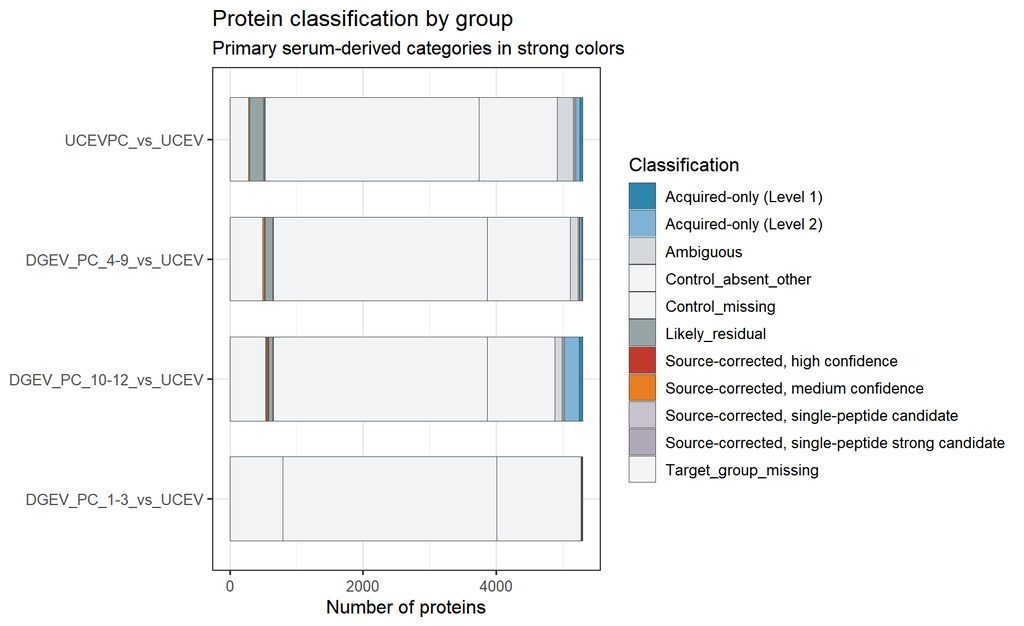

Stacked bar chart of classification counts per comparison

```r
plot_classification_summary(core$case_summary)
```

# 7 Primary Serum-derived Proteins

```r
cat(paste(primary_serum_categories(), collapse = "\n"), "\n")
```

```
## Acquired-only (Level 1)
## Acquired-only (Level 2)
## Source-corrected, high confidence
## Source-corrected, medium confidence
```

```r
cat("\nPrimary serum-derived proteins:", nrow(core$primary_serum), "\n")
```

```
##
## Primary serum-derived proteins: 535
```

```r
core$primary_serum %>%
  select(comparison, Protein_Row_ID, Gene_names, classification,
         Light_fraction_excess, estimated_serum_fraction, Database_evidence) %>%
  head(20) %>%
  kable(caption = "Top 20 primary serum-derived proteins")
```

Top 20 primary serum-derived proteins

| comparison | Protein_Row_ID | Gene_names | classification | Light_fraction_excess | estimated_serum_fraction | Database_evidence |
| --- | --- | --- | --- | --- | --- | --- |
| DGEV_PC_1-3_vs_UCEV | D9IWP9;A0A384NKM6;P02749;B4DPN0;J3KS17;J3QRN2;J3QLI0 | APOH | Acquired-only (Level 2) | NA | NA | In-house serum database + Human Plasma PeptideAtlas |
| DGEV_PC_1-3_vs_UCEV | A0A679KTH4 | EmGFP-LacZ-E2F-TdTom | Acquired-only (Level 2) | NA | NA | In-house serum database + Human Plasma PeptideAtlas |
| DGEV_PC_1-3_vs_UCEV | P31944;B2CIS9;A9UFC0 | CASP14 | Acquired-only (Level 1) | NA | NA | In-house serum database + Human Plasma PeptideAtlas |
| DGEV_PC_1-3_vs_UCEV | P02452;Q6LAN8;H9C5C5;Q9UMA6;T1RTD8;B7Z4S2 | COL1A1 | Acquired-only (Level 2) | NA | NA | In-house serum database + Human Plasma PeptideAtlas |
| DGEV_PC_1-3_vs_UCEV | A0A0S2Z3H5;A0A384MDU2;P08123 | COL1A2 | Acquired-only (Level 1) | NA | NA | In-house serum database + Human Plasma PeptideAtlas |
| DGEV_PC_1-3_vs_UCEV | P81605 | DCD | Acquired-only (Level 1) | NA | NA | In-house serum database + Human Plasma PeptideAtlas |
| DGEV_PC_1-3_vs_UCEV | I0B0K5;I0B0K6;I0B0K7;I0B0K8;CON__P20930;P20930;I0B0K3;I0B0K4;Q05331;Q4JFL9;Q59H78;Q16824;Q15206;Q01212 | FLG | Acquired-only (Level 2) | NA | NA | In-house serum database + Human Plasma PeptideAtlas |
| DGEV_PC_1-3_vs_UCEV | P47929 | LGALS7 | Acquired-only (Level 2) | NA | NA | In-house serum database + Human Plasma PeptideAtlas |
| DGEV_PC_1-3_vs_UCEV | P00738;J3QR68;H0Y300;A0A0C4DGL8;J3QLC9;Q6NSB4;Q6PEJ8;B3KP77;H3BS21;J3KRH2;J3KSV1;J3QQI8;H3BMJ7 | HP | Acquired-only (Level 2) | NA | NA | In-house serum database + Human Plasma PeptideAtlas |
| DGEV_PC_1-3_vs_UCEV | B2R4R0;P62805;Q0VAS5;Q6B823 | HIST1H4L | Source-corrected, high confidence | 0.3766371 | 0.3797444 | In-house serum database + Human Plasma PeptideAtlas |
| DGEV_PC_1-3_vs_UCEV | P01871 | IGHM | Acquired-only (Level 2) | NA | NA | In-house serum database + Human Plasma PeptideAtlas |
| DGEV_PC_1-3_vs_UCEV | P01591;D6RD17;D6RHJ6;C9JA05 | JCHAIN | Acquired-only (Level 2) | NA | NA | In-house serum database + Human Plasma PeptideAtlas |
| DGEV_PC_1-3_vs_UCEV | W8QEY1;P02788;Q2TUW9;A0A161I202;A8K494;B3VMW0;Q5EK51;B7ZAL5;E7EQB2;V9HWI4;E7ER44;B3KSL2;B2MV14;B4E1V0;Q19KS2;Q8IX02;C9JCF5;B4E1L2 | LTF | Acquired-only (Level 1) | NA | NA | In-house serum database + Human Plasma PeptideAtlas |
| DGEV_PC_1-3_vs_UCEV | B2R4C5;P61626;F8VV32;A0A0B4J259 | LYZ | Acquired-only (Level 2) | NA | NA | In-house serum database + Human Plasma PeptideAtlas |
| DGEV_PC_1-3_vs_UCEV | Q6EZE9;P59666;P59665 | DEFA3 | Acquired-only (Level 2) | NA | NA | In-house serum database + Human Plasma PeptideAtlas |
| DGEV_PC_1-3_vs_UCEV | A8K9G9;P48736 | PIK3CG | Acquired-only (Level 2) | NA | NA | In-house serum database + Human Plasma PeptideAtlas |
| DGEV_PC_1-3_vs_UCEV | P01275 | GCG | Acquired-only (Level 2) | NA | NA | In-house serum database + Human Plasma PeptideAtlas |
| DGEV_PC_1-3_vs_UCEV | Q8IYP2 | PRSS58 | Acquired-only (Level 2) | NA | NA | In-house serum database + Human Plasma PeptideAtlas |
| DGEV_PC_1-3_vs_UCEV | Q6UWP8 | SBSN | Acquired-only (Level 1) | NA | NA | In-house serum database + Human Plasma PeptideAtlas |
| DGEV_PC_1-3_vs_UCEV | A6XMV8;P07478;Q7Z5F3;A6XMV9;A0A0J9YYC8;Q5NV56;Q3SY20;Q3SY19;Q53ZX9;H0Y8D1;Q53ZX8;Q6PK75;A0A0J9YY49;Q86W17;Q45KI0;Q53ZX7;Q8NHM4 | PRSS2 | Acquired-only (Level 2) | NA | NA | In-house serum database + Human Plasma PeptideAtlas |

## 7.1 Light-fraction excess distribution

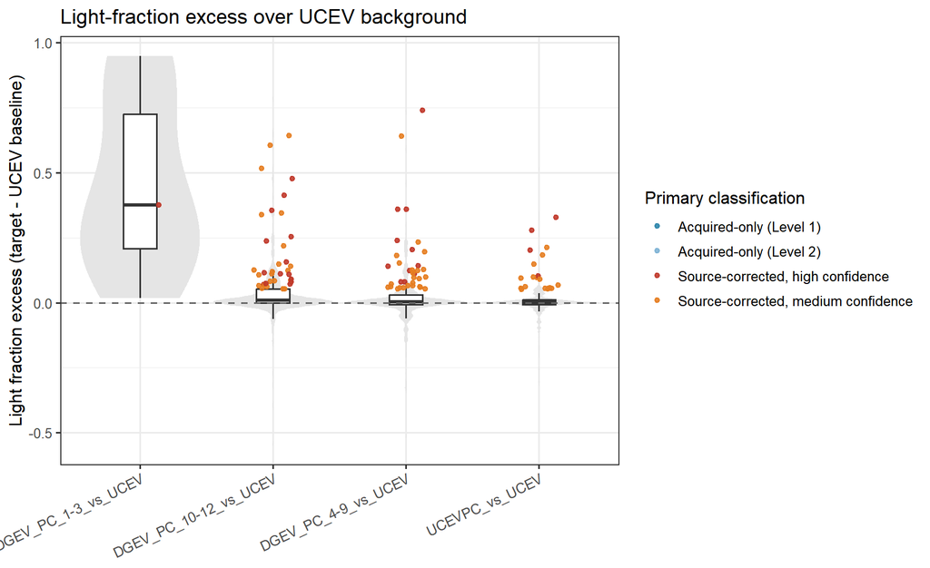

Light-fraction excess over UCEV background; primary categories highlighted

```r
plot_excess_distribution(core$results)
```

## 7.2 Estimated serum fractions

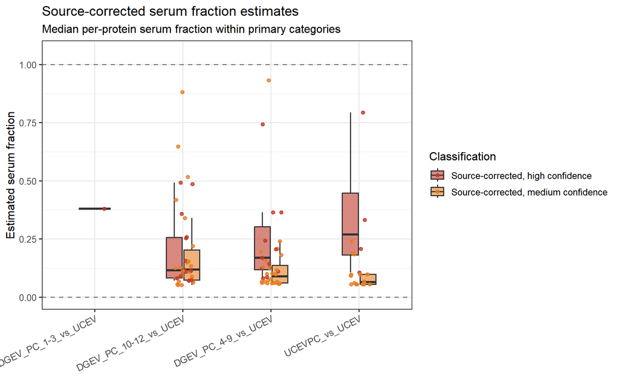

Source-corrected serum fraction estimates for primary categories

```r
plot_serum_fraction(core$results)
```

## 7.3 Excess vs statistical significance

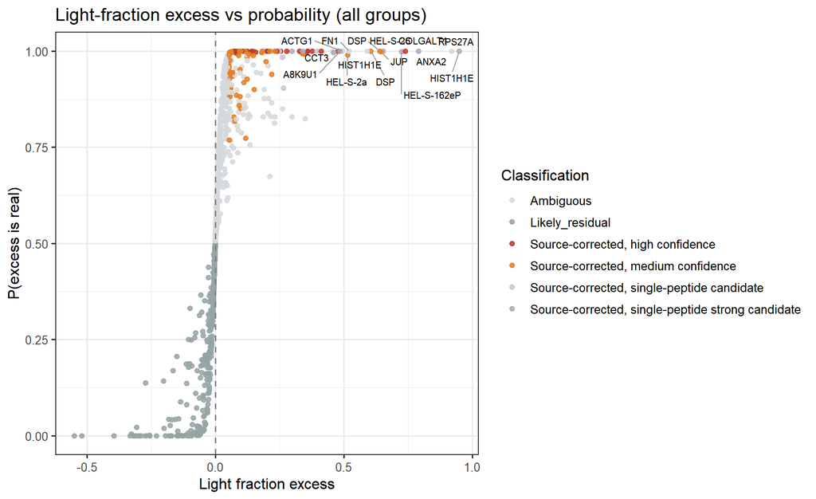

Volcano-style plot: Light-fraction excess vs P(excess is real)

```r
plot_excess_vs_probability(core$results, label_top_n = 15)
```

# 8 Database Evidence

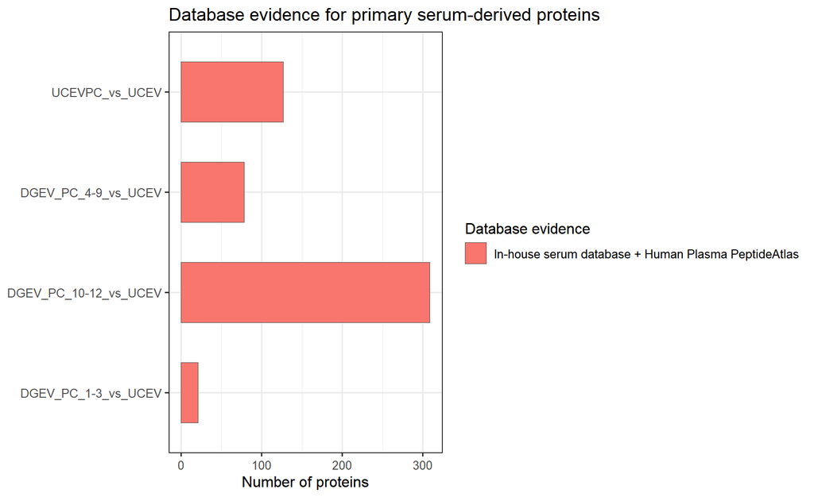

Database-evidence composition of primary serum-derived proteins

```r
plot_database_evidence(core$primary_serum)
```

```r
kable(core$database_summary, caption = "Database-annotation summary by comparison",
      row.names = FALSE)
```

Database-annotation summary by comparison

| comparison | Database_evidence | classification | protein_count |
| --- | --- | --- | --- |
| DGEV_PC_1-3_vs_UCEV | In-house serum database + Human Plasma PeptideAtlas | Acquired-only (Level 1) | 5 |
| DGEV_PC_1-3_vs_UCEV | In-house serum database + Human Plasma PeptideAtlas | Acquired-only (Level 2) | 15 |
| DGEV_PC_1-3_vs_UCEV | In-house serum database + Human Plasma PeptideAtlas | Ambiguous | 6 |
| DGEV_PC_1-3_vs_UCEV | In-house serum database + Human Plasma PeptideAtlas | Control_absent_other | 1264 |
| DGEV_PC_1-3_vs_UCEV | In-house serum database + Human Plasma PeptideAtlas | Control_missing | 3210 |
| DGEV_PC_1-3_vs_UCEV | In-house serum database + Human Plasma PeptideAtlas | Source-corrected, high confidence | 1 |
| DGEV_PC_1-3_vs_UCEV | In-house serum database + Human Plasma PeptideAtlas | Source-corrected, single-peptide strong candidate | 2 |
| DGEV_PC_1-3_vs_UCEV | In-house serum database + Human Plasma PeptideAtlas | Target_group_missing | 795 |
| DGEV_PC_10-12_vs_UCEV | In-house serum database + Human Plasma PeptideAtlas | Acquired-only (Level 1) | 49 |
| DGEV_PC_10-12_vs_UCEV | In-house serum database + Human Plasma PeptideAtlas | Acquired-only (Level 2) | 224 |
| DGEV_PC_10-12_vs_UCEV | In-house serum database + Human Plasma PeptideAtlas | Ambiguous | 149 |
| DGEV_PC_10-12_vs_UCEV | In-house serum database + Human Plasma PeptideAtlas | Control_absent_other | 1011 |
| DGEV_PC_10-12_vs_UCEV | In-house serum database + Human Plasma PeptideAtlas | Control_missing | 3210 |
| DGEV_PC_10-12_vs_UCEV | In-house serum database + Human Plasma PeptideAtlas | Likely_residual | 74 |
| DGEV_PC_10-12_vs_UCEV | In-house serum database + Human Plasma PeptideAtlas | Source-corrected, high confidence | 14 |
| DGEV_PC_10-12_vs_UCEV | In-house serum database + Human Plasma PeptideAtlas | Source-corrected, medium confidence | 22 |
| DGEV_PC_10-12_vs_UCEV | In-house serum database + Human Plasma PeptideAtlas | Source-corrected, single-peptide candidate | 3 |
| DGEV_PC_10-12_vs_UCEV | In-house serum database + Human Plasma PeptideAtlas | Source-corrected, single-peptide strong candidate | 5 |
| DGEV_PC_10-12_vs_UCEV | In-house serum database + Human Plasma PeptideAtlas | Target_group_missing | 537 |
| DGEV_PC_4-9_vs_UCEV | In-house serum database + Human Plasma PeptideAtlas | Acquired-only (Level 1) | 14 |
| DGEV_PC_4-9_vs_UCEV | In-house serum database + Human Plasma PeptideAtlas | Acquired-only (Level 2) | 29 |
| DGEV_PC_4-9_vs_UCEV | In-house serum database + Human Plasma PeptideAtlas | Ambiguous | 148 |
| DGEV_PC_4-9_vs_UCEV | In-house serum database + Human Plasma PeptideAtlas | Control_absent_other | 1241 |
| DGEV_PC_4-9_vs_UCEV | In-house serum database + Human Plasma PeptideAtlas | Control_missing | 3210 |
| DGEV_PC_4-9_vs_UCEV | In-house serum database + Human Plasma PeptideAtlas | Likely_residual | 125 |
| DGEV_PC_4-9_vs_UCEV | In-house serum database + Human Plasma PeptideAtlas | Source-corrected, high confidence | 11 |
| DGEV_PC_4-9_vs_UCEV | In-house serum database + Human Plasma PeptideAtlas | Source-corrected, medium confidence | 24 |
| DGEV_PC_4-9_vs_UCEV | In-house serum database + Human Plasma PeptideAtlas | Source-corrected, single-peptide candidate | 1 |
| DGEV_PC_4-9_vs_UCEV | In-house serum database + Human Plasma PeptideAtlas | Source-corrected, single-peptide strong candidate | 2 |
| DGEV_PC_4-9_vs_UCEV | In-house serum database + Human Plasma PeptideAtlas | Target_group_missing | 493 |
| UCEVPC_vs_UCEV | In-house serum database + Human Plasma PeptideAtlas | Acquired-only (Level 1) | 45 |
| UCEVPC_vs_UCEV | In-house serum database + Human Plasma PeptideAtlas | Acquired-only (Level 2) | 62 |
| UCEVPC_vs_UCEV | In-house serum database + Human Plasma PeptideAtlas | Ambiguous | 276 |
| UCEVPC_vs_UCEV | In-house serum database + Human Plasma PeptideAtlas | Control_absent_other | 1177 |
| UCEVPC_vs_UCEV | In-house serum database + Human Plasma PeptideAtlas | Control_missing | 3210 |
| UCEVPC_vs_UCEV | In-house serum database + Human Plasma PeptideAtlas | Likely_residual | 227 |
| UCEVPC_vs_UCEV | In-house serum database + Human Plasma PeptideAtlas | Source-corrected, high confidence | 4 |
| UCEVPC_vs_UCEV | In-house serum database + Human Plasma PeptideAtlas | Source-corrected, medium confidence | 16 |
| UCEVPC_vs_UCEV | In-house serum database + Human Plasma PeptideAtlas | Source-corrected, single-peptide candidate | 3 |
| UCEVPC_vs_UCEV | In-house serum database + Human Plasma PeptideAtlas | Source-corrected, single-peptide strong candidate | 1 |
| UCEVPC_vs_UCEV | In-house serum database + Human Plasma PeptideAtlas | Target_group_missing | 277 |

# 9 Excess Heatmap

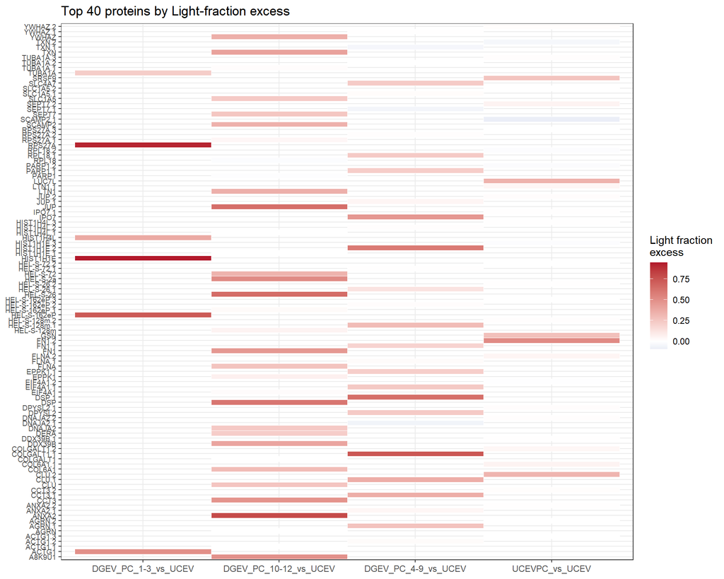

Heatmap of Light-fraction excess for top proteins across comparisons

```r
plot_excess_heatmap(core$results, top_n = 40)
```

# 10 Calibrated Serum Light Intensity

`all_merged` adds `Serum_L_Calibrated_<sample>` columns, converting each replicate’s excess into calibrated serum Light intensity units.

```r
cal_cols <- grep("^Serum_L_Calibrated", names(core$all_merged), value = TRUE)
cat("Calibrated columns added:", length(cal_cols), "\n")
```

```
## Calibrated columns added: 12
```

```r
core$all_merged %>%
  select(Protein_Row_ID, Gene_names, all_of(cal_cols[1:min(4, length(cal_cols))])) %>%
  head(10) %>%
  kable(caption = "Preview of calibrated serum Light intensity (first 4 samples)")
```

Preview of calibrated serum Light intensity (first 4 samples)

| Protein_Row_ID | Gene_names | Serum_L_Calibrated DGEV–PC_1-3_1 | Serum_L_Calibrated DGEV–PC_1-3_2 | Serum_L_Calibrated DGEV–PC_1-3_3 | Serum_L_Calibrated DGEV–PC_10-12_1 |
| --- | --- | --- | --- | --- | --- |
| Q9C0C9;K7ES11;K7EQ12 | UBE2O | NA | NA | NA | NA |
| B4E139;P52849;B4DVV6;B4DE98;B4DU70;S4R438 | NDST2 | NA | NA | NA | NA |
| Q75MP9;Q75MQ0;S4S3R8;A0A090N8E9;Q15910 | EZH2 | NA | NA | NA | NA |
| S4R3N1;A8K012;Q9Y3A3;B4DM50 | HSPE1-MOB4 | NA | NA | NA | NA |
| B3KX19;Q6IBM8;Q15029;Q8IXJ3;A8KAP3;B4DZB1;B3KWY2;K7EP67;K7EJ74;K7EIT3 | U5-116KD | NA | NA | NA | NA |
| V9HWC4;Q9NRX4;Q6FIE5;Q9P019 | HEL-S-132P | NA | NA | NA | NA |
| V9HWD6;P31946;B5BU24;Q4VY20;Q4VY19;A0A0J9YWE8;Q59EQ2;A0A0J9YWZ2 | HEL-S-1 | NA | NA | NA | NA |
| V9HW98;P62258;G9K389;G9K388;B4DJB0;B4DJF2;I3L3T1;B7ZA86;K7EM20;K7EIT4;I3L0W5;B3KT37 | HEL2 | NA | NA | NA | NA |
| Q04917;B2R6N6;Q9H4N8;A2IDB2;F8WEB6;A2IDB1 | YWHAH | NA | NA | NA | NA |
| P61981;B4DE78;B3KNB4;B4DHC4 | YWHAG | NA | NA | NA | NA |

# 11 Save Outputs

One call writes all CSV tables, the XLSX workbook and the Markdown report.

```r
run_downstream_analysis(
  core_result     = core,
  input_file      = input_file,
  output_dir      = output_dir,
  sample_info     = sample_info,
  reference_group = reference_group,
  target_groups   = target_groups,
  params          = params,
  make_plots      = FALSE,
  save_outputs    = TRUE,
  write_report    = FALSE,
  render_notebook = FALSE
)

cat("Output files (", length(list.files(output_dir, recursive = TRUE)), "):\n", sep = "")
```

```
## Output files (48):
```

```r
print(list.files(output_dir, recursive = TRUE))
```

```
##  [1] "00_All_Comparisons_Merged_Results.csv"
##  [2] "00_All_Comparisons_Primary_Serum_Derived_Merged.csv"
##  [3] "00_Classification_Summary_by_Group.csv"
##  [4] "00_Database_Annotation_Summary_All_Groups.csv"
##  [5] "01_sample_information.csv"
##  [6] "02_protein_database_annotation.csv"
##  [7] "04_UCEV_background_variation.csv"
##  [8] "DGEV_PC_1-3_vs_UCEV/DGEV_PC_1-3_vs_UCEV_00_All_Results.csv"
##  [9] "DGEV_PC_1-3_vs_UCEV/DGEV_PC_1-3_vs_UCEV_01_Merged_Primary_Serum_Derived_Proteins.csv"
## [10] "DGEV_PC_1-3_vs_UCEV/DGEV_PC_1-3_vs_UCEV_02_Acquired_only_Level1.csv"
## [11] "DGEV_PC_1-3_vs_UCEV/DGEV_PC_1-3_vs_UCEV_03_Acquired_only_Level2.csv"
## [12] "DGEV_PC_1-3_vs_UCEV/DGEV_PC_1-3_vs_UCEV_04_Source_corrected_High_Confidence.csv"
## [13] "DGEV_PC_1-3_vs_UCEV/DGEV_PC_1-3_vs_UCEV_05_Source_corrected_Medium_Confidence.csv"
## [14] "DGEV_PC_1-3_vs_UCEV/DGEV_PC_1-3_vs_UCEV_06_Source_corrected_Single_Peptide_Candidates.csv"
## [15] "DGEV_PC_1-3_vs_UCEV/DGEV_PC_1-3_vs_UCEV_07_Likely_Residual.csv"
```

[output cut: 33 more lines]